# Quick analysis of PE Schools data

# Introduction

These are a set of research notes that help keep me on track, record my thoughts and ideas. Each of the data tables can be worked upon further (to create percentage results, for instance) or for visualisation in Tableau Public, Datawrapper etc.

We’re reading in manually cleaned data from a CSV exported from OpenRefine. The original data was scraped from the bio pages of 15 private equity firms, and the names of the educational establishments captured using Mechanical Turk.

All data requires some cleaning & “munging”, but unstructured data are harder. People went to:

- The University of Oxford
- Oxford University
- Oxford
- Balliol (a college at Oxford which considers itself prestigious)

Sometimes there are misspellings (“Carnegie Mellow University”), or technical errors (Paul Farber of TPG is so good they [hired him twice](https://www.tpg.com/team/who-we-are?title=&field_platforms_target_id=All&field_region_target_id=294&sort_by=field_last_name_value&sort_order=ASC&page=3) - also Derek Chen.)

```r
data = read.csv("~/Documents/Private Equity Data Harvest/openrefine/PE-Schools-2018-12-13.csv") %>%
  select(company = file,
         region,
         region2,
         name,
         education,
         school)
```

The companies for which we collected data are listed below in alphabetical order. `n` indicates the number of records per company.

```r
data %>%
  select(company) %>%
  group_by(company) %>%
  tally()
```

| company | n |
| --- | --- |
| advent | 346 |
| apax | 227 |
| apollo | 250 |
| bain-capital | 705 |
| blackstone | 929 |
| bpea | 79 |
| carlyle | 752 |
| cinven | 122 |
| cvc | 345 |
| eqt | 368 |

[output cut: 5 more lines]

## People-based views (In Progress)

Note that the counts beside the company names don’t represent *people*, but rather the number of *qualifications* held by the people at that firm. If you have two qualifications, you’ll appear twice in the records. Many of the people have more than one degree:

```r
data %>%
  select(education) %>%
  group_by(education) %>%
  tally() %>%
  spread(education, n) %>%
  mutate("single degree" = school1 - (school2 + school3),
         "two degrees" = school2 - school3,
         "three or more" = school3) %>%
  select(-starts_with("school"))
```

| single degree | two degrees | three or more |
| --- | --- | --- |
| 1687 | 1566 | 212 |

Let’s break that down by company – who employs the most eggheads?

```r
data %>%
  select(company, education) %>%
  group_by(company, education) %>%
  tally() %>%
  spread(education, n) %>%
  mutate("single degree" = school1 - (school2 + school3),
         "two degrees" = school2 - school3,
         "three or more" = school3) %>%
  select(-starts_with("school")) %>%
  arrange(desc(`three or more`)) ->  # backticks fix whitespace
  eggheads

eggheads
```

| company | single degree | two degrees | three or more |
| --- | --- | --- | --- |
| carlyle | 208 | 212 | 30 |
| bain-capital | 143 | 225 | 28 |
| blackstone | 301 | 258 | 28 |
| kkr | 194 | 198 | 27 |
| eqt | 94 | 87 | 25 |
| advent | 94 | 102 | 12 |
| apax | 65 | 57 | 12 |
| cvc | 127 | 87 | 11 |
| permira | 84 | 68 | 9 |
| apollo | 82 | 68 | 8 |

[output cut: 5 more lines]

We really need to look at this in terms of percentages.

```r
# note to self - be careful, `total` increments with rowsum leading to misleadingly low percentages.
eggheads$total = rowSums(eggheads[,-1])
eggheads %>%
  mutate(`single degree%` = (`single degree`/total)*100,
         `two degrees%` = (`two degrees`/total)*100,
         `three or more%` = (`three or more`/total)*100) %>%
  select(company, contains("%")) %>%
  arrange(desc(`three or more%`))
```

| company | single degree% | two degrees% | three or more% |
| --- | --- | --- | --- |
| eqt | 45.63107 | 42.23301 | 12.135922 |
| bpea | 30.95238 | 59.52381 | 9.523810 |
| apax | 48.50746 | 42.53731 | 8.955224 |
| bain-capital | 36.11111 | 56.81818 | 7.070707 |
| carlyle | 46.22222 | 47.11111 | 6.666667 |
| kkr | 46.30072 | 47.25537 | 6.443914 |
| advent | 45.19231 | 49.03846 | 5.769231 |
| permira | 52.17391 | 42.23602 | 5.590062 |
| tpg | 40.64516 | 54.19355 | 5.161290 |
| apollo | 51.89873 | 43.03797 | 5.063291 |

[output cut: 5 more lines]

## Summary of other data

Here’s a quick summary of the rest of the data in the 5667 records in the dataset – it’s all words, not numbers.

- We collected data on at least 3672 individuals (note - some names - e.g. Sarah Smith - are common to more than one company. This all comes out in the wash - we break down by name & company. As long as no company has hired -say- *two* Sarah Smiths, we should be alright)
- There are 1118 individual schools in the dataset. Some of the longtail ones may still be incorrectly coded

Note that `region` and `region2` refer to the office in which the partner/associate works, and were manually coded based on location data contained in the bio.

- There are 5457 records that contain `region` macro-region data.

```r
data %>% select(region) %>% filter(region != "") %>% group_by(region) %>% tally() %>% arrange(desc(n))
```

| region | n |
| --- | --- |
| Americas | 3086 |
| EMEA | 1581 |
| APAC | 790 |

- `region2` is a more granular field with more missing data. Only 5098 records contain `region2` data.

```r
data %>% select(region2) %>% filter(region2 != "") %>% group_by(region2) %>% tally() %>% arrange(desc(n))
```

| region2 | n |
| --- | --- |
| North America | 2770 |
| Europe | 1462 |
| East Asia | 491 |
| South Asia | 107 |
| Latin America | 96 |
| Southeast Asia | 86 |
| Oceania | 46 |
| Africa | 21 |
| Middle East | 19 |

We should probably code more data for `school` - to enrich for *region* and *category* (e.g. to let us break out Business Schools and Law Schools as a minimum - maybe Med Schools etc as well.)

# Which are the most popular schools?

How often does each turn up in the dataset?

```r
data %>%
  select(school) %>%
  group_by(school) %>%
  tally() %>%
  arrange(desc(n)) ->
  schools

schools
```

| school | n |
| --- | --- |
| Harvard Business School | 346 |
| Wharton | 238 |
| Harvard | 162 |
| University of Pennsylvania | 103 |
| Oxford | 92 |
| Cambridge | 89 |
| Columbia | 89 |
| Princeton | 89 |
| London School of Economics | 82 |
| Columbia Business School | 74 |

[output cut: 1108 more lines]

We’ll plot that table

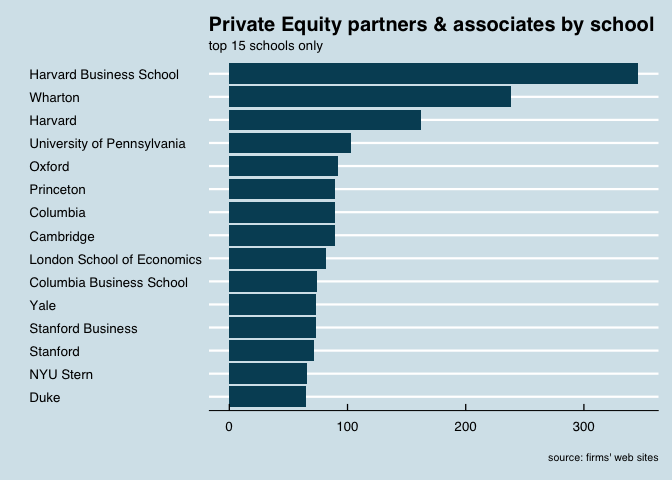

```r
schools %>%
  head(15) %>%
  ggplot(aes(fct_reorder(school, n), n)) +
  geom_col(fill = blue) +
  theme_economist() +
  coord_flip() +
  labs(title="Private Equity partners & associates by school",
       subtitle="top 15 schools only",
       caption="source: firms' web sites",
       y="", x="")
```

Now let’s create a list of the top 100 schools. It’s probably going to come in handy later; in the meantime it gives us another way of looking at these data. Note that undergraduate and graduate (business, law) schools are all jumbled together. We’ll need to separate those.

```r
top_schools <- as.character(head(schools$school,100))
as.tibble(top_schools)
```

| value |
| --- |
| Harvard Business School |
| Wharton |
| Harvard |
| University of Pennsylvania |
| Oxford |
| Cambridge |
| Columbia |
| Princeton |
| London School of Economics |
| Columbia Business School |

[output cut: 90 more lines]

# Breakdown by company & schools

Now we’ll break the dataset down by company and schools - creating a sparse matrix that shows how many qualifications from each school are held by people at each firm. That’s an ugly, but accurate sentence.

```r
data %>%
  select(company, school) %>%
  group_by(school, company) %>%
  tally() %>%
  spread(company, n) ->
  schools_by_company
```

We’ll impose some frequency order - we’ll sum the columns and the rows, and present them in descending order. The most popular school will be in the first row - and the most *populous* firm in the first column.

```r
schools_by_company[order(rowSums(-schools_by_company, na.rm = TRUE)), order(colSums(-schools_by_company, na.rm = TRUE))] %>%
  select(school, everything()) ->  # quick hack to move the 'school' column into the first slot
  schools_by_company

schools_by_company
```

| school | blackstone | carlyle | bain-capital | kkr | eqt | advent | cvc | tpg | permira | apollo | apax | silver-lake | partners-group | cinven | bpea |
| --- | --- | --- | --- | --- | --- | --- | --- | --- | --- | --- | --- | --- | --- | --- | --- |
| Harvard Business School | 43 | 43 | 85 | 32 | 5 | 34 | 17 | 23 | 13 | 11 | 22 | 7 | 3 | 5 | 3 |
| Wharton | 45 | 36 | 25 | 25 | 5 | 14 | 11 | 18 | 4 | 17 | 12 | 17 | 3 | 1 | 5 |
| Harvard | 28 | 19 | 38 | 20 | 5 | 10 | 5 | 11 | 3 | 12 | 1 | 7 | NA | 3 | NA |
| University of Pennsylvania | 20 | 12 | 14 | 18 | 3 | 10 | 7 | 4 | 1 | 4 | 2 | 4 | 2 | 1 | 1 |
| Oxford | 7 | 10 | 7 | 5 | 2 | 10 | 14 | 3 | 11 | 1 | 5 | 2 | 1 | 11 | 3 |
| Cambridge | 7 | 8 | 13 | 8 | 7 | 2 | 11 | 3 | 7 | 1 | 11 | 2 | 1 | 8 | NA |
| Columbia | 28 | 8 | 12 | 12 | 3 | 4 | 4 | 1 | 2 | 10 | 2 | 1 | NA | NA | 2 |
| Princeton | 16 | 12 | 21 | 15 | NA | 2 | 6 | 1 | 2 | 5 | 2 | 4 | 1 | 2 | NA |
| London School of Economics | 8 | 5 | 3 | 11 | 12 | 8 | 10 | 1 | 5 | 1 | 8 | 6 | NA | 2 | 2 |
| Columbia Business School | 9 | 10 | 5 | 16 | 5 | 1 | 8 | 4 | 4 | 4 | 3 | 1 | 1 | 1 | 2 |

[output cut: 1108 more lines]

Glancing at this, there are some clear anomalies - Silver Lake, for instance. Might there be an East Coast/West Coast story to be told? We’d need to categorise US colleges by - say - timezone or state (with some further iterations on state.)

Here are the schools that feed Silver Lake

```r
count_qualifications <- function(c){
  data %>%
  filter(company == c) %>%
  select(school) %>%
  group_by(school) %>%
  tally() %>%
  arrange(desc(n))
}

count_qualifications("silver-lake")
```

| school | n |
| --- | --- |
| Wharton | 17 |
| UC Berkeley | 10 |
| Stanford | 9 |
| Harvard | 7 |
| Harvard Business School | 7 |
| Ivey Business School | 6 |
| London School of Economics | 6 |
| Duke | 4 |
| Princeton | 4 |
| University of Pennsylvania | 4 |

[output cut: 97 more lines]

There are interesting patterns for EQT and Permira as well - probably for all the non-US firms.

Equally, we can split by school. Let’s take a look at the UC Berkeley figures

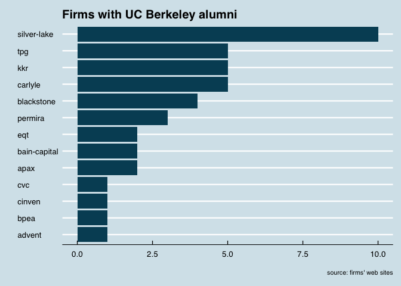

```r
count_companies <- function(s) {
  data %>%
  filter(school == "UC Berkeley") %>%
  select(company) %>%
  group_by(company) %>%
  tally() %>%
  arrange(desc(n)) %>%
  ggplot(aes(fct_reorder(company, n), n)) +
  geom_col(fill=blue) +
  theme_economist() +
  coord_flip() +
  labs(title=paste("Firms with", s, "alumni", sep=" "),
       caption="source: firms' web sites", y="", x="")

}

count_companies("UC Berkeley")
```

Alternatively, we could take a view of the `schools_by_company` type matrix where we only look at the UC schools

```r
data %>%
  select(company, school) %>%
  filter(str_detect(school, "^UC")) %>%
  group_by(school, company) %>%
  tally() %>%
  spread(company, n) ->
  UC_schools

UC_schools[order(rowSums(-UC_schools, na.rm = TRUE)), order(colSums(-UC_schools, na.rm = TRUE))] %>%
  select(school, everything())
```

| school | kkr | tpg | blackstone | silver-lake | carlyle | bain-capital | permira | apax | apollo | cvc | advent | cinven | eqt | bpea | partners-group |
| --- | --- | --- | --- | --- | --- | --- | --- | --- | --- | --- | --- | --- | --- | --- | --- |
| UC Berkeley | 5 | 5 | 4 | 10 | 5 | 2 | 3 | 2 | NA | 1 | 1 | 1 | 2 | 1 | NA |
| UCLA | 3 | 6 | 3 | NA | 1 | 2 | NA | 1 | NA | 1 | 1 | NA | NA | NA | 1 |
| UC San Diego | 1 | 1 | NA | NA | 2 | NA | NA | NA | 1 | 1 | NA | 1 | NA | NA | NA |
| UCD Smurfitt | NA | NA | 3 | NA | 1 | NA | NA | NA | 1 | NA | NA | NA | NA | NA | NA |
| UCLA Anderson | 3 | NA | NA | NA | NA | 1 | 1 | NA | NA | NA | NA | NA | NA | NA | NA |
| UC Davis | NA | 2 | 1 | 1 | NA | NA | NA | NA | NA | NA | NA | NA | NA | NA | NA |
| UC Santa Barbara | 1 | NA | NA | 1 | 1 | NA | NA | NA | 1 | NA | NA | NA | NA | NA | NA |
| UCLA Law | 1 | NA | 1 | NA | NA | 1 | NA | NA | NA | NA | NA | NA | NA | NA | NA |
| UC Hastings Law | 1 | 1 | NA | NA | NA | NA | NA | NA | NA | NA | NA | NA | NA | NA | NA |
| UC Irvine | 1 | NA | NA | NA | NA | NA | NA | NA | NA | NA | NA | NA | NA | NA | NA |

Similarly, there are several Indian Institutes of Technology.

```r
data %>%
  select(company, school) %>%
  filter(str_detect(school, "^Indian Institute of Technology")) %>%
  group_by(school, company) %>%
  tally() %>%
  spread(company, n) ->
  IIT_schools

IIT_schools[order(rowSums(-IIT_schools, na.rm = TRUE)), order(colSums(-IIT_schools, na.rm = TRUE))] %>%
  select(school, everything())
```

| school | apax | carlyle | kkr | blackstone | tpg | advent | apollo | bain-capital | cvc | silver-lake |
| --- | --- | --- | --- | --- | --- | --- | --- | --- | --- | --- |
| Indian Institute of Technology - Bombay | 2 | 3 | NA | 1 | NA | NA | NA | NA | NA | 1 |
| Indian Institute of Technology - Delhi | 2 | NA | 1 | NA | 1 | NA | NA | NA | 1 | NA |
| Indian Institute of Technology - Kharagpur | NA | 1 | 1 | NA | 1 | 1 | NA | NA | NA | NA |
| Indian Institute of Technology - Madras | 1 | NA | 1 | NA | NA | NA | 1 | 1 | NA | NA |
| Indian Institute of Technology - Guwahati | NA | NA | NA | 1 | NA | NA | NA | NA | NA | NA |
| Indian Institute of Technology - Kanpur | NA | NA | 1 | NA | NA | NA | NA | NA | NA | NA |

## Summarise by an arbitrary vector of schools

It’s almost certainly going to be useful to perform something like the UC & IIT exercises above for an arbitrary, manually-selected vector (list) of schools. Let’s create that as a general function - as an example, we’ll use:

- ESCP Europe
- ESSEC Business School
- European Business School
- HEC Paris
- INSEAD
- London Business School

```r
count_specific_schools <- function(s){
  data %>%
  select(company, school) %>%
  filter(str_detect(school, paste(s, collapse = "|"))) %>%
  group_by(school, company) %>%
  tally() %>%
  spread(company, n) ->
  selected_schools

selected_schools[order(rowSums(-selected_schools, na.rm = TRUE)),
                 order(colSums(-selected_schools, na.rm = TRUE))] %>%
  select(school, everything())

}

# let's test it...

schools_select <- c("INSEAD",
                    "London Business School",
                    "HEC Paris",
                    "ESCP Europe",
                    "ESSEC Business School",
                    "European Business School")

count_specific_schools(schools_select)
```

| school | advent | carlyle | eqt | kkr | cvc | permira | apax | bain-capital | blackstone | cinven | partners-group | apollo | silver-lake | tpg | bpea |
| --- | --- | --- | --- | --- | --- | --- | --- | --- | --- | --- | --- | --- | --- | --- | --- |
| HEC Paris | 10 | 4 | 6 | 8 | 4 | 7 | 1 | 4 | 1 | 5 | 1 | 1 | 1 | NA | NA |
| INSEAD | 2 | 8 | 5 | 3 | 6 | 5 | 5 | 3 | 2 | 1 | 3 | 1 | NA | 2 | 1 |
| London Business School | 5 | 6 | 3 | 6 | 2 | 2 | NA | NA | 1 | 1 | NA | NA | NA | 2 | NA |
| ESCP Europe | 3 | 4 | 1 | NA | 3 | 2 | 1 | NA | 2 | 1 | NA | NA | 1 | NA | NA |
| ESSEC Business School | 1 | 1 | 1 | 3 | 2 | 1 | 1 | 1 | 2 | NA | 1 | 1 | 1 | NA | NA |
| European Business School | 3 | 1 | 5 | 1 | 2 | 1 | NA | NA | NA | NA | 1 | 1 | 1 | NA | NA |

## Ivy League

```r
ivy_league <- c("Brown University",
                "Columbia",
                "Cornell",
                "Dartmouth",
                "Harvard",
                "Princeton",
                "University of Pennsylvania",
                "Yale")

count_specific_schools(ivy_league)
```

| school | bain-capital | blackstone | kkr | carlyle | advent | tpg | apollo | cvc | apax | silver-lake | permira | eqt | cinven | bpea | partners-group |
| --- | --- | --- | --- | --- | --- | --- | --- | --- | --- | --- | --- | --- | --- | --- | --- |
| Harvard Business School | 85 | 43 | 32 | 43 | 34 | 23 | 11 | 17 | 22 | 7 | 13 | 5 | 5 | 3 | 3 |
| Harvard | 38 | 28 | 20 | 19 | 10 | 11 | 12 | 5 | 1 | 7 | 3 | 5 | 3 | NA | NA |
| University of Pennsylvania | 14 | 20 | 18 | 12 | 10 | 4 | 4 | 7 | 2 | 4 | 1 | 3 | 1 | 1 | 2 |
| Columbia | 12 | 28 | 12 | 8 | 4 | 1 | 10 | 4 | 2 | 1 | 2 | 3 | NA | 2 | NA |
| Princeton | 21 | 16 | 15 | 12 | 2 | 1 | 5 | 6 | 2 | 4 | 2 | NA | 2 | NA | 1 |
| Columbia Business School | 5 | 9 | 16 | 10 | 1 | 4 | 4 | 8 | 3 | 1 | 4 | 5 | 1 | 2 | 1 |
| Yale | 15 | 10 | 13 | 9 | 2 | 10 | 2 | 2 | 2 | 3 | 4 | NA | NA | NA | 1 |
| Cornell | 4 | 25 | 14 | 8 | 1 | NA | 3 | 2 | 2 | NA | 1 | 1 | NA | NA | 2 |
| Dartmouth | 12 | 4 | 8 | 9 | 4 | 4 | 3 | 1 | 2 | 2 | 1 | 1 | NA | NA | 1 |
| Brown University | 7 | 8 | 2 | 6 | NA | 3 | NA | 2 | 3 | NA | 1 | NA | NA | 1 | NA |

[output cut: 20 more lines]

## Russell Group

Often treated as an equivalent of Ivy League.

```r
russell_group <- c("Cambridge",
                   "Oxford",
                   "University of Warwick",
                   "University of Leeds",
                   "University of Birmingham",
                   "University of Manchester",
                   "University of Edinburgh",
                   "University of Bristol",
                   "University of Southampton",
                   "University of Sheffield",
                   "Newcastle University",
                   "University of Nottingham",
                   "University of Liverpool",
                   "University of Glasgow",
                   "Cardiff University",
                   "University College London",
                   "Imperial College London",
                   "King's College London",
                   "London School of Economics")

count_specific_schools(russell_group)
```

| school | cvc | permira | blackstone | apax | bain-capital | cinven | kkr | carlyle | eqt | advent | apollo | silver-lake | tpg | bpea | partners-group |
| --- | --- | --- | --- | --- | --- | --- | --- | --- | --- | --- | --- | --- | --- | --- | --- |
| Oxford | 14 | 11 | 7 | 5 | 7 | 11 | 5 | 10 | 2 | 10 | 1 | 2 | 3 | 3 | 1 |
| Cambridge | 11 | 7 | 7 | 11 | 13 | 8 | 8 | 8 | 7 | 2 | 1 | 2 | 3 | NA | 1 |
| London School of Economics | 10 | 5 | 8 | 8 | 3 | 2 | 11 | 5 | 12 | 8 | 1 | 6 | 1 | 2 | NA |
| Imperial College London | 1 | 3 | 3 | 1 | 2 | 2 | 2 | 1 | 2 | 3 | NA | NA | 1 | NA | 1 |
| University College London | 3 | 4 | 3 | 3 | 2 | 2 | NA | NA | NA | NA | 2 | NA | 1 | NA | NA |
| University of Edinburgh | NA | 2 | 1 | 1 | 2 | 2 | 1 | NA | 1 | NA | 2 | NA | NA | NA | NA |
| University of Warwick | 2 | NA | 2 | NA | 1 | 3 | 2 | 1 | NA | 1 | NA | NA | NA | NA | NA |
| University of Nottingham | 1 | 1 | 2 | 2 | NA | NA | 1 | 1 | NA | 1 | NA | NA | 1 | NA | 1 |
| University of Bristol | 1 | 1 | 1 | 3 | 1 | NA | 1 | NA | NA | NA | NA | NA | NA | 1 | NA |
| University of Leeds | NA | 2 | NA | 1 | 1 | 1 | 1 | 1 | 2 | NA | NA | NA | NA | NA | NA |

[output cut: 10 more lines]

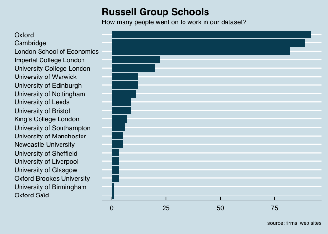

```r
plot_schools <- function(s){
  data %>%
  select(school) %>%
  filter(str_detect(school, paste(s, collapse = "|"))) %>%
  group_by(school) %>%
  tally() %>%
  arrange(desc(n)) %>%
  ggplot(aes(fct_reorder(school, n), n)) +
  geom_col(fill = blue) +
  theme_economist() +
  coord_flip() +
  labs(title="Russell Group Schools",
       subtitle="How many people went on to work in our dataset?",
       caption="source: firms' web sites",
       y="", x="")
}

plot_schools(russell_group)
```

## FT European Business Schools

The FT publishes a handy list of European Business School rankings. This could provide a great media hook for 2019 - possibly even worth talking to them ahead of time.

I’ve [used a Google Sheet to capture the data](https://docs.google.com/spreadsheets/d/1iDUJfBc6ETgZ-crpHdisY4eWqdSw7Iq8ncP4evKd1oU/) and manually matched the school names in OpenRefine. Let’s read in the data and see what we can do.

```r
read_csv("~/Documents/Private Equity Data Harvest/openrefine/FT-Top-European-Business-Schools-2018.csv") %>%
  select(school = "Reconciled Name",
         rank = "Rank 2018",
         country = "Reconciled Country") ->
  ft_data

count_specific_schools(ft_data$school)
```

| school | eqt | permira | advent | kkr | cvc | carlyle | bain-capital | partners-group | blackstone | apax | cinven | silver-lake | tpg | apollo | bpea |
| --- | --- | --- | --- | --- | --- | --- | --- | --- | --- | --- | --- | --- | --- | --- | --- |
| HEC Paris | 6 | 7 | 10 | 8 | 4 | 4 | 4 | 1 | 1 | 1 | 5 | 1 | NA | 1 | NA |
| Università Bocconi | 2 | 11 | 2 | 7 | 4 | 2 | 10 | NA | 5 | 4 | 1 | 1 | 1 | NA | NA |
| Stockholm School of Economics | 33 | 2 | 2 | NA | 2 | NA | 4 | 1 | 2 | 1 | 1 | NA | NA | NA | NA |
| INSEAD | 5 | 5 | 2 | 3 | 6 | 8 | 3 | 3 | 2 | 5 | 1 | NA | 2 | 1 | 1 |
| University of St. Gallen | 17 | NA | 3 | 1 | NA | NA | NA | 17 | 1 | NA | 1 | 1 | NA | NA | NA |
| London Business School | 3 | 2 | 5 | 6 | 2 | 6 | NA | NA | 1 | NA | 1 | NA | 2 | NA | NA |
| Copenhagen Business School | 15 | 1 | 1 | 1 | 1 | NA | 2 | NA | NA | 1 | 1 | NA | NA | NA | NA |
| ESCP Europe | 1 | 2 | 3 | NA | 3 | 4 | NA | NA | 2 | 1 | 1 | 1 | NA | NA | NA |
| Cass Business School | 2 | 1 | NA | 1 | 1 | 2 | 1 | NA | 2 | 1 | NA | NA | NA | NA | NA |
| NHH Norwegian School of Economics | 6 | NA | NA | 1 | 1 | NA | 3 | NA | NA | NA | NA | NA | NA | NA | NA |

[output cut: 29 more lines]

OK, let’s do that again, but this time rank by the FT’s preference

```r
data %>%
  select(company, school) %>%
  group_by(school, company) %>%
  tally() %>%
  merge(ft_data)  %>%
  select(rank, everything()) %>%
  spread(company, n) %>%
  arrange(rank) -> ft_order
```

Adding a total column per school

```r
ft_order %>%
  mutate(total = select(., 4:18) %>% rowSums(na.rm = TRUE)) %>%
  select(rank, school, country, total, everything())
```

| rank | school | country | total | advent | apax | apollo | bain-capital | blackstone | bpea | carlyle | cinven | cvc | eqt | kkr | partners-group | permira | silver-lake | tpg |
| --- | --- | --- | --- | --- | --- | --- | --- | --- | --- | --- | --- | --- | --- | --- | --- | --- | --- | --- |
| 1 | London Business School | UK | 28 | 5 | NA | NA | NA | 1 | NA | 6 | 1 | 2 | 3 | 6 | NA | 2 | NA | 2 |
| 2 | HEC Paris | France | 53 | 10 | 1 | 1 | 4 | 1 | NA | 4 | 5 | 4 | 6 | 8 | 1 | 7 | 1 | NA |
| 3 | INSEAD | France | 47 | 2 | 5 | 1 | 3 | 2 | 1 | 8 | 1 | 6 | 5 | 3 | 3 | 5 | NA | 2 |
| 4 | University of St. Gallen | Switzerland | 41 | 3 | NA | NA | NA | 1 | NA | NA | 1 | NA | 17 | 1 | 17 | NA | 1 | NA |
| 5 | IESE Business School | Spain | 1 | NA | NA | NA | NA | NA | NA | 1 | NA | NA | NA | NA | NA | NA | NA | NA |
| 6 | Università Bocconi | Italy | 50 | 2 | 4 | NA | 10 | 5 | NA | 2 | 1 | 4 | 2 | 7 | NA | 11 | 1 | 1 |
| 7 | IMD Business School | Switzerland | 7 | 1 | NA | NA | NA | NA | NA | NA | NA | 2 | NA | NA | 2 | 1 | 1 | NA |
| 9 | Rotterdam School of Management, Erasmus University | Netherlands | 3 | 1 | NA | NA | NA | NA | NA | NA | NA | NA | 1 | NA | NA | NA | 1 | NA |
| 10 | Oxford Saïd | UK | 1 | NA | NA | NA | NA | 1 | NA | NA | NA | NA | NA | NA | NA | NA | NA | NA |
| 11 | ESCP Europe | NA | 18 | 3 | 1 | NA | NA | 2 | NA | 4 | 1 | 3 | 1 | NA | NA | 2 | 1 | NA |

[output cut: 30 more lines]

We can split out the UK schools

```r
ft_order %>%
  filter(country == "UK") %>%
  mutate(total = select(., 4:18) %>% rowSums(na.rm = TRUE)) %>%
  select(rank, school, country, total, everything())
```

| rank | school | country | total | advent | apax | apollo | bain-capital | blackstone | bpea | carlyle | cinven | cvc | eqt | kkr | partners-group | permira | silver-lake | tpg |
| --- | --- | --- | --- | --- | --- | --- | --- | --- | --- | --- | --- | --- | --- | --- | --- | --- | --- | --- |
| 1 | London Business School | UK | 28 | 5 | NA | NA | NA | 1 | NA | 6 | 1 | 2 | 3 | 6 | NA | 2 | NA | 2 |
| 10 | Oxford Saïd | UK | 1 | NA | NA | NA | NA | 1 | NA | NA | NA | NA | NA | NA | NA | NA | NA | NA |
| 12 | Warwick Business School | UK | 5 | NA | 1 | NA | NA | NA | NA | NA | NA | 1 | 2 | NA | NA | 1 | NA | NA |
| 16 | Cass Business School | UK | 11 | NA | 1 | NA | 1 | 2 | NA | 2 | NA | 1 | 2 | 1 | NA | 1 | NA | NA |
| 38 | Alliance Manchester Business School | UK | 1 | NA | NA | NA | NA | NA | NA | NA | NA | NA | NA | NA | 1 | NA | NA | NA |
| 47 | Durham University Business School | UK | 1 | NA | NA | NA | NA | NA | NA | NA | NA | NA | NA | NA | NA | 1 | NA | NA |
| 58 | Leeds University Business School | UK | 1 | NA | NA | NA | NA | NA | NA | NA | NA | NA | NA | 1 | NA | NA | NA | NA |
| 59 | University of Bath School of Management | UK | 1 | 1 | NA | NA | NA | NA | NA | NA | NA | NA | NA | NA | NA | NA | NA | NA |

Or the French schools

```r
ft_order %>%
  filter(country == "France") %>%
  mutate(total = select(., 4:18) %>% rowSums(na.rm = TRUE)) %>%
  select(rank, school, country, total, everything())
```

| rank | school | country | total | advent | apax | apollo | bain-capital | blackstone | bpea | carlyle | cinven | cvc | eqt | kkr | partners-group | permira | silver-lake | tpg |
| --- | --- | --- | --- | --- | --- | --- | --- | --- | --- | --- | --- | --- | --- | --- | --- | --- | --- | --- |
| 2 | HEC Paris | France | 53 | 10 | 1 | 1 | 4 | 1 | NA | 4 | 5 | 4 | 6 | 8 | 1 | 7 | 1 | NA |
| 3 | INSEAD | France | 47 | 2 | 5 | 1 | 3 | 2 | 1 | 8 | 1 | 6 | 5 | 3 | 3 | 5 | NA | 2 |
| 14 | EDHEC Business School | France | 4 | 1 | NA | NA | NA | NA | NA | NA | NA | NA | 1 | 1 | NA | 1 | NA | NA |
| 21 | EMLYON Business School | France | 6 | 1 | NA | NA | NA | NA | NA | 2 | NA | 1 | 1 | NA | NA | 1 | NA | NA |
| 45 | NEOMA Business School | France | 2 | NA | 1 | NA | NA | NA | NA | NA | NA | NA | 1 | NA | NA | NA | NA | NA |
| 64 | IESEG School of Management | France | 1 | NA | NA | NA | NA | NA | NA | NA | NA | NA | NA | NA | NA | NA | 1 | NA |
| 83 | Université Paris-Dauphine | France | 5 | 1 | NA | NA | NA | 2 | NA | NA | NA | NA | 1 | 1 | NA | NA | NA | NA |

Or the Scandi schools

```r
ft_order %>%
  filter(country == "Sweden"| country == "Denmark" |country == "Norway"| country == "Finland") %>%
  mutate(total = select(., 4:18) %>% rowSums(na.rm = TRUE)) %>%
  select(rank, school, country, total, everything())
```

| rank | school | country | total | advent | apax | apollo | bain-capital | blackstone | bpea | carlyle | cinven | cvc | eqt | kkr | partners-group | permira | silver-lake | tpg |
| --- | --- | --- | --- | --- | --- | --- | --- | --- | --- | --- | --- | --- | --- | --- | --- | --- | --- | --- |
| 25 | Stockholm School of Economics | Sweden | 48 | 2 | 1 | NA | 4 | 2 | NA | NA | 1 | 2 | 33 | NA | 1 | 2 | NA | NA |
| 33 | Copenhagen Business School | Denmark | 23 | 1 | 1 | NA | 2 | NA | NA | NA | 1 | 1 | 15 | 1 | NA | 1 | NA | NA |
| 34 | Aalto University | Finland | 2 | NA | NA | NA | NA | NA | NA | NA | NA | NA | 2 | NA | NA | NA | NA | NA |
| 39 | NHH Norwegian School of Economics | Norway | 11 | NA | NA | NA | 3 | NA | NA | NA | NA | 1 | 6 | 1 | NA | NA | NA | NA |
| 77 | Hanken School of Economics | Finland | 1 | NA | NA | NA | NA | NA | NA | NA | NA | NA | NA | NA | NA | 1 | NA | NA |

## Economist/WhichMBA? ranking

The Economist produces an [annual table of MBA schools](https://www.economist.com/whichmba/full-time-mba-ranking). Again, this is both useful data and a potential news hook. we scraped the tables, and manually recoded the data in Excel.

```r
library(readxl)
read_excel("~/Documents/Private Equity Data Harvest/openrefine/Economist-MBA-2018-list.xlsx",
           sheet = "Economist MBA 2018 list") %>%
  select(rank, school=`reconciled name`, country) ->
  economist_schools
```

```r
data %>%
  select(company, school) %>%
  group_by(school, company) %>%
  tally() %>%
  merge(economist_schools)  %>%
  select(rank, everything()) %>%
  spread(company, n) %>%
  arrange(rank)
```

| rank | school | country | advent | apax | apollo | bain-capital | blackstone | bpea | carlyle | cinven | cvc | eqt | kkr | partners-group | permira | silver-lake | tpg |
| --- | --- | --- | --- | --- | --- | --- | --- | --- | --- | --- | --- | --- | --- | --- | --- | --- | --- |
| 1 | Chicago Booth | United States | 1 | 1 | 1 | 5 | 9 | NA | 2 | NA | NA | 1 | 7 | 4 | NA | NA | 2 |
| 2 | Kellogg School of Management | United States | 3 | 2 | 1 | 5 | 5 | NA | 2 | 1 | 3 | 1 | 3 | NA | 2 | 3 | 3 |
| 3 | Harvard Business School | United States | 34 | 22 | 11 | 85 | 43 | 3 | 43 | 5 | 17 | 5 | 32 | 3 | 13 | 7 | 23 |
| 4 | Wharton | United States | 14 | 12 | 17 | 25 | 45 | 5 | 36 | 1 | 11 | 5 | 25 | 3 | 4 | 17 | 18 |
| 5 | Stanford Business | United States | 2 | 4 | 6 | 8 | 3 | 1 | 10 | 1 | 4 | 2 | 11 | NA | 6 | 3 | 12 |
| 6 | IESE Business School | Spain | NA | NA | NA | NA | NA | NA | 1 | NA | NA | NA | NA | NA | NA | NA | NA |
| 7 | Michigan Ross | United States | 1 | 4 | NA | 1 | 3 | NA | 5 | NA | NA | 3 | 2 | NA | NA | NA | 2 |
| 8 | UCLA Anderson | United States | NA | NA | NA | 1 | NA | NA | NA | NA | NA | NA | 3 | NA | 1 | NA | NA |
| 9 | Virginia Darden | United States | NA | NA | NA | 2 | 2 | NA | 1 | NA | NA | NA | NA | NA | NA | NA | NA |
| 10 | Columbia Business School | United States | 1 | 3 | 4 | 5 | 9 | 2 | 10 | 1 | 8 | 5 | 16 | 1 | 4 | 1 | 4 |

[output cut: 50 more lines]

# Geographical breakdown

We’ve got some tentative regional breakdowns indicating where the partners are based. Let’s try to put that to use.

```r
data %>%
  select(region2, school) %>%
  filter(region2 != "") %>%
  group_by(school, region2) %>%
  tally() %>%
  spread(region2, n) ->
  schools_by_region
```

We’ll use the same ordering as the schools-by-company matrix

```r
schools_by_region[order(rowSums(-schools_by_region, na.rm = TRUE)), order(colSums(-schools_by_region, na.rm = TRUE))] %>%
  select(school, everything()) ->  # quick hack to move the 'school' column into the first slot
  schools_by_region

schools_by_region
```

| school | North America | Europe | East Asia | South Asia | Latin America | Southeast Asia | Oceania | Africa | Middle East |
| --- | --- | --- | --- | --- | --- | --- | --- | --- | --- |
| Harvard Business School | 214 | 49 | 30 | 6 | 9 | 3 | 6 | 2 | NA |
| Wharton | 158 | 17 | 24 | 7 | 2 | 4 | 1 | 1 | 2 |
| Harvard | 122 | 17 | 6 | 1 | NA | NA | 2 | 1 | NA |
| University of Pennsylvania | 72 | 13 | 9 | NA | NA | 2 | NA | NA | NA |
| Columbia | 62 | 11 | 11 | NA | NA | 1 | NA | NA | 1 |
| Princeton | 74 | 5 | 3 | NA | 1 | 2 | NA | NA | NA |
| London School of Economics | 9 | 57 | 7 | 1 | 2 | 3 | NA | NA | NA |
| Cambridge | 9 | 56 | 7 | 1 | NA | 1 | 1 | NA | 1 |
| Oxford | 11 | 52 | 5 | 1 | NA | 5 | NA | NA | NA |
| Columbia Business School | 43 | 15 | 5 | NA | NA | 3 | NA | 1 | 1 |

[output cut: 1022 more lines]

We’ll adapt that general-purpose function for looking at a subset of schools

```r
count_specific_schools_region <- function(s){
  data %>%
  select(school, region2) %>%
  filter(region2 != "") %>%
  filter(str_detect(school, paste(s, collapse = "|"))) %>%
  group_by(school, region2) %>%
  tally() %>%
  spread(region2, n) ->
  selected_schools_region

selected_schools_region[order(rowSums(-selected_schools_region, na.rm = TRUE)),
                 order(colSums(-selected_schools_region, na.rm = TRUE))] %>%
  select(school, everything())

}

# let's test it...

schools_select <- c("INSEAD",
                    "London Business School",
                    "HEC Paris",
                    "ESCP Europe",
                    "ESSEC Business School",
                    "European Business School")

count_specific_schools_region(schools_select)
```

| school | Europe | East Asia | North America | Latin America | Southeast Asia | Africa | Middle East | South Asia |
| --- | --- | --- | --- | --- | --- | --- | --- | --- |
| HEC Paris | 44 | NA | 2 | NA | NA | NA | 1 | NA |
| INSEAD | 27 | 7 | 4 | 2 | 1 | 1 | NA | NA |
| London Business School | 11 | 3 | 4 | 3 | 1 | NA | NA | 1 |
| ESCP Europe | 17 | NA | NA | NA | NA | NA | NA | NA |
| ESSEC Business School | 15 | NA | NA | NA | NA | NA | NA | NA |
| European Business School | 15 | NA | NA | NA | NA | NA | NA | NA |

## South Asia

Now let’s set up a function for looking at just one region - we’ll test with South Asia

```r
count_regional_qualifications <- function(r){
  data %>%
  filter(region2 == r) %>%
  select(school) %>%
  group_by(school) %>%
  tally() %>%
  arrange(desc(n))
}

count_regional_qualifications("South Asia")
```

| school | n |
| --- | --- |
| Indian Institute of Management - Ahmedabad | 11 |
| University of Mumbai | 8 |
| Wharton | 7 |
| Harvard Business School | 6 |
| University of Delhi | 6 |
| Indian Institute of Management - Calcutta | 4 |
| Indian Institute of Technology - Bombay | 4 |
| Indian Institute of Technology - Madras | 4 |
| Indian Institute of Management - Bangalore | 3 |
| Indian Institute of Management - Lucknow | 3 |

[output cut: 41 more lines]

## Europe

```r
count_regional_qualifications("Europe")
```

| school | n |
| --- | --- |
| London School of Economics | 57 |
| Cambridge | 56 |
| Oxford | 52 |
| Harvard Business School | 49 |
| Stockholm School of Economics | 45 |
| Università Bocconi | 45 |
| HEC Paris | 44 |
| INSEAD | 27 |
| University College Dublin | 25 |
| University of St. Gallen | 21 |

[output cut: 468 more lines]

## Latin America

```r
count_regional_qualifications("Latin America")
```

| school | n |
| --- | --- |
| Harvard Business School | 9 |
| FGV | 6 |
| Universidad de los Andes | 6 |
| Instituto Tecnológico de Aeronáutica | 5 |
| Universidade de São Paulo | 5 |
| FGV-EAESP | 4 |
| London Business School | 3 |
| Stanford Business | 3 |
| Universidad del Pacífico | 3 |
| Universidad Iberoamericana | 3 |

[output cut: 39 more lines]

## North America

```r
count_regional_qualifications("North America")
```

| school | n |
| --- | --- |
| Harvard Business School | 214 |
| Wharton | 158 |
| Harvard | 122 |
| Princeton | 74 |
| University of Pennsylvania | 72 |
| Columbia | 62 |
| Yale | 52 |
| Cornell | 51 |
| Duke | 50 |
| NYU Stern | 47 |

[output cut: 528 more lines]

## East Asia

```r
count_regional_qualifications("East Asia")
```

| school | n |
| --- | --- |
| Harvard Business School | 30 |
| Wharton | 24 |
| Keio University | 21 |
| University of Tokyo | 21 |
| Peking University | 15 |
| Columbia | 11 |
| Fudan University | 10 |
| Seoul National University | 9 |
| University of Pennsylvania | 9 |
| Kellogg School of Management | 8 |

[output cut: 181 more lines]

# Network Graph Visualisation (In Progress)

We need to create a list of edges - there’s a simple way and a complex way. The simple way may actually be more accurate - select the school and company - graph that.

## Build out vertices & edges data

We’ll append an “organisation type” column for later aesthetics

```r
vertices <- rbind(tibble(label = levels(data$company), orgtype = "company"),
      tibble(label = levels(data$school), orgtype = "school"))

vertices
```

| label | orgtype |
| --- | --- |
| advent | company |
| apax | company |
| apollo | company |
| bain-capital | company |
| blackstone | company |
| bpea | company |
| carlyle | company |
| cinven | company |
| cvc | company |
| eqt | company |

[output cut: 1123 more lines]

and the edges…

```r
data %>%
  select(source = school, target = company) %>%
  group_by(source, target) %>%
  tally() %>%
  arrange(desc(n)) %>%
  rename(weight = n) ->
  edges

edges
```

| source | target | weight |
| --- | --- | --- |
| Harvard Business School | bain-capital | 85 |
| Wharton | blackstone | 45 |
| Harvard Business School | blackstone | 43 |
| Harvard Business School | carlyle | 43 |
| Harvard | bain-capital | 38 |
| Wharton | carlyle | 36 |
| Harvard Business School | advent | 34 |
| Stockholm School of Economics | eqt | 33 |
| Harvard Business School | kkr | 32 |
| Columbia | blackstone | 28 |

[output cut: 2601 more lines]

We can write the nodes & edges to csv for import to Gephi